# Netflixproject

```python
import pandas as pd
import numpy as np
import matplotlib.pyplot as plt
import seaborn as sns
```

```python
netflix_df=pd.read_csv('netflix1 (2).csv')
```

```python
netflix_df.head()
```

|  | show_id | type | title | director | country | date_added | release_year | rating | duration | listed_in |
| --- | --- | --- | --- | --- | --- | --- | --- | --- | --- | --- |
| 0 | s1 | Movie | Dick Johnson Is Dead | Kirsten Johnson | United States | 9/25/2021 | 2020 | PG-13 | 90 min | Documentaries |
| 1 | s3 | TV Show | Ganglands | Julien Leclercq | France | 9/24/2021 | 2021 | TV-MA | 1 Season | Crime TV Shows, International TV Shows, TV Act... |
| 2 | s6 | TV Show | Midnight Mass | Mike Flanagan | United States | 9/24/2021 | 2021 | TV-MA | 1 Season | TV Dramas, TV Horror, TV Mysteries |
| 3 | s14 | Movie | Confessions of an Invisible Girl | Bruno Garotti | Brazil | 9/22/2021 | 2021 | TV-PG | 91 min | Children & Family Movies, Comedies |
| 4 | s8 | Movie | Sankofa | Haile Gerima | United States | 9/24/2021 | 1993 | TV-MA | 125 min | Dramas, Independent Movies, International Movies |

```python
netflix_df.info()
```

```
<class 'pandas.core.frame.DataFrame'>
RangeIndex: 8790 entries, 0 to 8789
Data columns (total 10 columns):
 #   Column        Non-Null Count  Dtype
---  ------        --------------  -----
 0   show_id       8790 non-null   object
 1   type          8790 non-null   object
 2   title         8790 non-null   object
 3   director      8790 non-null   object
 4   country       8790 non-null   object
 5   date_added    8790 non-null   object
 6   release_year  8790 non-null   int64
 7   rating        8790 non-null   object
 8   duration      8790 non-null   object
 9   listed_in     8790 non-null   object
dtypes: int64(1), object(9)
memory usage: 686.8+ KB
```

```python
netflix_df.isnull().sum()
```

```
show_id         0
type            0
title           0
director        0
country         0
date_added      0
release_year    0
rating          0
duration        0
listed_in       0
dtype: int64
```

```python
netflix_df.shape
```

```
(8790, 10)
```

```python
netflix_df.isnull().value_counts()
```

```
show_id  type   title  director  country  date_added  release_year  rating  duration  listed_in
False    False  False  False     False    False       False         False   False     False        8790
Name: count, dtype: int64
```

```python
data= netflix_df.drop_duplicates()
```

```python
data.head()
```

|  | show_id | type | title | director | country | date_added | release_year | rating | duration | listed_in |
| --- | --- | --- | --- | --- | --- | --- | --- | --- | --- | --- |
| 0 | s1 | Movie | Dick Johnson Is Dead | Kirsten Johnson | United States | 9/25/2021 | 2020 | PG-13 | 90 min | Documentaries |
| 1 | s3 | TV Show | Ganglands | Julien Leclercq | France | 9/24/2021 | 2021 | TV-MA | 1 Season | Crime TV Shows, International TV Shows, TV Act... |
| 2 | s6 | TV Show | Midnight Mass | Mike Flanagan | United States | 9/24/2021 | 2021 | TV-MA | 1 Season | TV Dramas, TV Horror, TV Mysteries |
| 3 | s14 | Movie | Confessions of an Invisible Girl | Bruno Garotti | Brazil | 9/22/2021 | 2021 | TV-PG | 91 min | Children & Family Movies, Comedies |
| 4 | s8 | Movie | Sankofa | Haile Gerima | United States | 9/24/2021 | 1993 | TV-MA | 125 min | Dramas, Independent Movies, International Movies |

```python
data['release_year']=pd.to_datetime(data['release_year'])
data['Years']=data['release_year'].dt.year
```

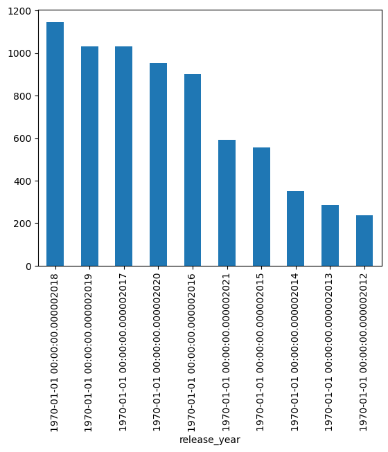

```python
year = data.release_year.value_counts()
year[:10].plot(kind = 'bar')
```

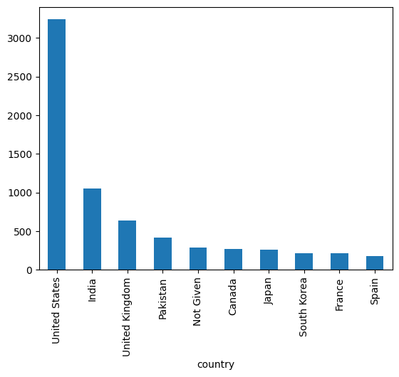

```python
top_10_country = data.country.value_counts()
top_10_country[:10].plot(kind = 'bar')
```

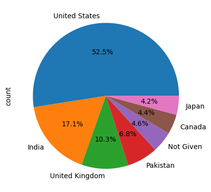

```python
data_country = data.country.value_counts()
data_country[:7].plot(kind = 'pie',autopct ='%1.1f%%')
```

```python
data.rating.value_counts()
```

```
rating
TV-MA       3205
TV-14       2157
TV-PG        861
R            799
PG-13        490
TV-Y7        333
TV-Y         306
PG           287
TV-G         220
NR            79
G             41
TV-Y7-FV       6
NC-17          3
UR             3
Name: count, dtype: int64
```

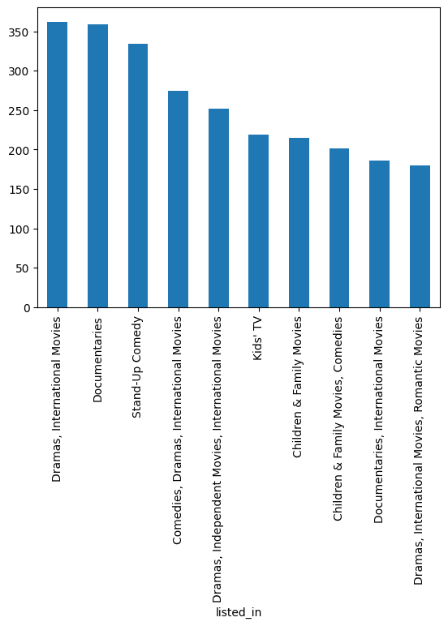

```python
##Most ratings are given to the TV shows in the Dataset


top_10_types = data.listed_in.value_counts()
top_10_types[:10].plot(kind = 'bar')
```

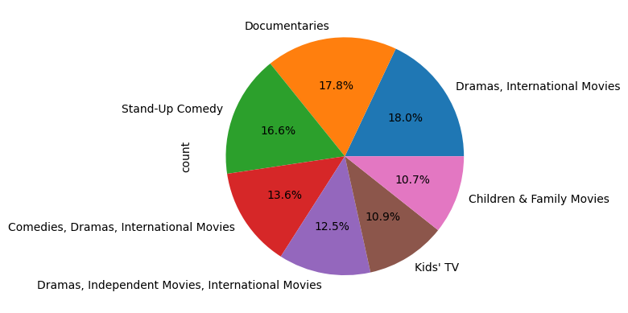

```python
data_list= data.listed_in.value_counts()
data_list[:7].plot(kind = 'pie',autopct ='%1.1f%%')
```

Netflix Data: Cleaning, Analysis, and Visualization (Beginner ML Project) This project involves loading, cleaning, analyzing, and visualizing data from a Netflix dataset. We'll use Python libraries like Pandas, Matplotlib, and Seaborn to work through the project. The goal is to explore the dataset, derive insights, and prepare for potential machine learning tasks.

```python
from wordcloud import WordCloud
```

```python
df = pd.read_csv('netflix1 (2).csv')
df.head(10)
```

|  | show_id | type | title | director | country | date_added | release_year | rating | duration | listed_in |
| --- | --- | --- | --- | --- | --- | --- | --- | --- | --- | --- |
| 0 | s1 | Movie | Dick Johnson Is Dead | Kirsten Johnson | United States | 9/25/2021 | 2020 | PG-13 | 90 min | Documentaries |
| 1 | s3 | TV Show | Ganglands | Julien Leclercq | France | 9/24/2021 | 2021 | TV-MA | 1 Season | Crime TV Shows, International TV Shows, TV Act... |
| 2 | s6 | TV Show | Midnight Mass | Mike Flanagan | United States | 9/24/2021 | 2021 | TV-MA | 1 Season | TV Dramas, TV Horror, TV Mysteries |
| 3 | s14 | Movie | Confessions of an Invisible Girl | Bruno Garotti | Brazil | 9/22/2021 | 2021 | TV-PG | 91 min | Children & Family Movies, Comedies |
| 4 | s8 | Movie | Sankofa | Haile Gerima | United States | 9/24/2021 | 1993 | TV-MA | 125 min | Dramas, Independent Movies, International Movies |
| 5 | s9 | TV Show | The Great British Baking Show | Andy Devonshire | United Kingdom | 9/24/2021 | 2021 | TV-14 | 9 Seasons | British TV Shows, Reality TV |
| 6 | s10 | Movie | The Starling | Theodore Melfi | United States | 9/24/2021 | 2021 | PG-13 | 104 min | Comedies, Dramas |
| 7 | s939 | Movie | Motu Patlu in the Game of Zones | Suhas Kadav | India | 5/1/2021 | 2019 | TV-Y7 | 87 min | Children & Family Movies, Comedies, Music & Mu... |
| 8 | s13 | Movie | Je Suis Karl | Christian Schwochow | Germany | 9/23/2021 | 2021 | TV-MA | 127 min | Dramas, International Movies |
| 9 | s940 | Movie | Motu Patlu in Wonderland | Suhas Kadav | India | 5/1/2021 | 2013 | TV-Y7 | 76 min | Children & Family Movies, Music & Musicals |

```python
# To see the high level data details
df.info()
```

```
<class 'pandas.core.frame.DataFrame'>
RangeIndex: 8790 entries, 0 to 8789
Data columns (total 10 columns):
 #   Column        Non-Null Count  Dtype
---  ------        --------------  -----
 0   show_id       8790 non-null   object
 1   type          8790 non-null   object
 2   title         8790 non-null   object
 3   director      8790 non-null   object
 4   country       8790 non-null   object
 5   date_added    8790 non-null   object
 6   release_year  8790 non-null   int64
 7   rating        8790 non-null   object
 8   duration      8790 non-null   object
 9   listed_in     8790 non-null   object
dtypes: int64(1), object(9)
memory usage: 686.8+ KB
```

```python
def missing_pct(df):
    # Calculate missing value and their percentage for each column
    missing_count_percent = df.isnull().sum() * 100 / df.shape[0]
    df_missing_count_percent = pd.DataFrame(missing_count_percent).round(2)
    df_missing_count_percent = df_missing_count_percent.reset_index().rename(
                    columns={
                            'index':'Column',
                            0:'Missing_Percentage (%)'
                    }
                )
    df_missing_value = df.isnull().sum()
    df_missing_value = df_missing_value.reset_index().rename(
                    columns={
                            'index':'Column',
                            0:'Missing_value_count'
                    }
                )
    # Sort the data frame
    #df_missing = df_missing.sort_values('Missing_Percentage (%)', ascending=False)
    Final = df_missing_value.merge(df_missing_count_percent, how = 'inner', left_on = 'Column', right_on = 'Column')
    Final = Final.sort_values(by = 'Missing_Percentage (%)',ascending = False)
    return Final

missing_pct(df)
```

|  | Column | Missing_value_count | Missing_Percentage (%) |
| --- | --- | --- | --- |
| 0 | show_id | 0 | 0.0 |
| 1 | type | 0 | 0.0 |
| 2 | title | 0 | 0.0 |
| 3 | director | 0 | 0.0 |
| 4 | country | 0 | 0.0 |
| 5 | date_added | 0 | 0.0 |
| 6 | release_year | 0 | 0.0 |
| 7 | rating | 0 | 0.0 |
| 8 | duration | 0 | 0.0 |
| 9 | listed_in | 0 | 0.0 |

The function missing_pct takes a data frame as an input and returns a data frame, where each row corresponds to a column in the original dataframe and contains column's name, number of missing values in that column as well as percentage of the missing values.

This is a standard template that I use for every dataset that I want to analyze.

Handling the missing data and deleting duplicates It is important to handle missing data because any statistical results based on a dataset with non-random missing values could be biased. So you really want to see if these are random or non-random missing values.

Drop the columns which has high number of missing values.

We can impute(filling the missing values using the available information such as mean, median) but we should carefully see the pattern of the column before doing imputation.

For example - You want to fill the height of a person who male. Simpley adding 0 in the missing column would not make sense. So we can take the averega of male height and use that value inplace of missing values.

Rating - manually filling the data usin data from Netflix website

Country - replacing blank countries with the most common country

```python
# Rating data is mentioned incorrectly for few titles in the input file. Hence correcting it by checking the Maturity rating online

df['rating'] = df['rating'].replace({'74 min': 'TV-MA', '84 min': 'TV-MA', '66 min': 'TV-MA'})
df['rating'] = df['rating'].replace({'TV-Y7-FV': 'TV-Y7'})
```

```python
df['rating'].unique()
```

```
array(['PG-13', 'TV-MA', 'TV-PG', 'TV-14', 'TV-Y7', 'TV-Y', 'PG', 'TV-G',
       'R', 'G', 'NC-17', 'NR', 'UR'], dtype=object)
```

```python
# Renaming vaules for Rating for better understanding
# Source : https://help.netflix.com/en/node/2064
df['rating'] = df['rating'].replace({
                'PG-13': 'Teens - Age above 12',
                'TV-MA': 'Adults',
                'PG': 'Kids - with parental guidence',
                'TV-14': 'Teens - Age above 14',
                'TV-PG': 'Kids - with parental guidence',
                'TV-Y': 'Kids',
                'TV-Y7': 'Kids - Age above 7',
                'R': 'Adults',
                'TV-G': 'Kids',
                 'G': 'Kids',
                'NC-17': 'Adults',
                'NR': 'NR',
                'UR' : 'UR'

})
```

```python
df['rating'].unique()
```

```
array(['Teens - Age above 12', 'Adults', 'Kids - with parental guidence',
       'Teens - Age above 14', 'Kids - Age above 7', 'Kids', 'NR', 'UR'],
      dtype=object)
```

```python
import numpy as np
import pandas as pd

# Example: check if columns exist before applying operations
if 'country' in df.columns:
    df['country'] = df['country'].fillna(df['country'].mode()[0])

if 'cast' in df.columns:
    df['cast'].replace(np.nan, 'No Data', inplace=True)

if 'director' in df.columns:
    df['director'].replace(np.nan, 'No Data', inplace=True)

# Drop any remaining missing values
df.dropna(inplace=True)

# Drop duplicates
df.drop_duplicates(inplace=True)
```

```python
print(df.columns.tolist())
```

```
['show_id', 'type', 'title', 'director', 'country', 'date_added', 'release_year', 'rating', 'duration', 'listed_in']
```

```python
# splitting the genres in different rows to use it in the viz later

#df_genre = df[df['title'].isin(['Blood & Water', 'Dick Johnson Is Dead', 'Ganglands' ])]
df_genre = df[['show_id', 'title','type', 'listed_in' ]]
df_genre = (df_genre.drop('listed_in', axis=1)
             .join
             (
             df_genre.listed_in
             .str
             .split(', ',expand=True)
             .stack()
             .reset_index(drop=True, level=1)
             .rename('listed_in')
             ))
```

```python
# Creating new columns

df['month'] = pd.DatetimeIndex(df['date_added']).month
```

```python
# Total Shows and movies

df_count = df['show_id'].count().sum()
print(df_count)
# Split of showes and TV
df_type = df.groupby('type')['show_id'].count().reset_index()
df_type = df_type.rename(columns = {"show_id":"count_showids"})
```

```
8790
```

```python
from plotly.subplots import make_subplots
```

```python
import plotly.graph_objects as go
```

```python
import plotly.graph_objects as go
from plotly.subplots import make_subplots

# Example DataFrame (replace with your actual data)
# df_type = your dataframe with 'type' and 'count_showids'

# Create subplot: 1 row, 2 columns
fig = make_subplots(rows=1, cols=2, specs=[[{'type': 'bar'}, {'type': 'pie'}]])

# Add horizontal bar chart
fig.add_trace(
    go.Bar(
        x=df_type['count_showids'],
        y=df_type['type'],
        orientation='h',
        marker=dict(color=["Maroon", "Grey"]),
        showlegend=False,
        text=df_type['count_showids'],
        textposition='auto'
    ),
    row=1, col=1
)

# Add pie chart
fig.add_trace(
    go.Pie(
        labels=df_type['type'],
        values=df_type['count_showids'],
        marker_colors=["Maroon", "Grey"]
    ),
    row=1, col=2
)

fig.update_layout(title_text="Content Type Distribution")
fig.show()
```

[interactive chart not shown]

```python
# splitting the countries in different rows
#df_genre = df[df['title'].isin(['Blood & Water', 'Dick Johnson Is Dead', 'Ganglands' ])]
df_country = df[['show_id', 'title','type', 'country' ]]
df_country = (df_country.drop('country', axis=1)
             .join
             (
             df_country.country
             .str
             .split(', ',expand=True)
             .stack()
             .reset_index(drop=True, level=1)
             .rename('country')
             ))
```

```python
import plotly.express as px
```

```python
df_country_viz = df_country[["title", "country"]]
df_country_viz = df_country_viz.groupby(['country'])["title"].count().reset_index().sort_values('title', ascending= False).head(10)
```

```python
import plotly.express as px

# Step 1: Total content count per country (top 10)
df_country_viz_total = df_country[["title", "country"]]
df_country_viz_total = (
    df_country_viz_total.groupby(['country'])["title"]
    .count()
    .reset_index()
    .sort_values('title', ascending=False)
    .head(10)
    .rename(columns={"title": "total_content_count"})
)

# Step 2: Content count per country split by type (movie/TV)
df_country_viz1 = df_country[["title", "type", "country"]]
df_country_viz1 = (
    df_country_viz1.groupby(['country', 'type'])["title"]
    .count()
    .reset_index()
    .rename(columns={"title": "movies_count"})
)

# Step 3: Merge and calculate percentage share
final1 = df_country_viz_total.merge(df_country_viz1, how='left', on='country')
final1['percentage'] = (final1['movies_count'] / final1['total_content_count']) * 100
final1['percentage'] = final1['percentage'].round(1)
final1['percent_string'] = final1['percentage'].astype(str) + '%'

# Step 4: Plot
fig2 = px.bar(
    final1,
    x='country',
    y='percentage',
    color='type',
    title='Top 10 countries with Movie/TV Show split'
)
fig2.show()
```

[interactive chart not shown]

```python
import plotly.express as px

# Step 1: Get top 10 countries by content count
df_country_viz_total = (
    df_country[["title", "country"]]
    .groupby("country")["title"]
    .count()
    .reset_index()
    .rename(columns={"title": "total_content_count"})
    .sort_values("total_content_count", ascending=False)
    .head(10)
)

# Step 2: Get content count by country and type (movie or TV show)
df_country_viz1 = (
    df_country[["title", "type", "country"]]
    .groupby(["country", "type"])["title"]
    .count()
    .reset_index()
    .rename(columns={"title": "type_count"})  # ✅ Use a clear column name
)

# Step 3: Merge the two datasets
final1 = df_country_viz_total.merge(df_country_viz1, how="left", on="country")

# Step 4: Calculate percentage share by type
final1["percentage"] = (final1["type_count"] / final1["total_content_count"]) * 100
final1["percentage"] = final1["percentage"].round(1)
final1["percent_string"] = final1["percentage"].astype(str) + "%"

# Step 5: Plot
fig2 = px.bar(
    final1,
    x="country",
    y="percentage",
    color="type",
    title="Top 10 Countries: Movie/TV Show Content Split (%)"
)
fig2.show()
```

[interactive chart not shown]

```python
df_2 = df.query("type == 'Movie'")
df_2 = df_2[["title", "rating"]]
df_2 = df_2.groupby(['rating'])["title"].count().reset_index().sort_values('title', ascending = False)
df_2 = df_2.rename(columns = {"title": "movies_count"})
px.bar(df_2, x='rating', y='movies_count', color_discrete_sequence=px.colors.sequential.RdBu,
       title='For which category the maximum content(Movies) are uploaded? ')
```

[interactive chart not shown]

```python
df_3 = df.query("type == 'TV Show'")
df_3 = df_3[["title", "rating"]]
df_3 = df_3.groupby('rating')["title"].count().reset_index().sort_values('title', ascending = False)
df_3 = df_3.rename(columns = {"title": "movies_count"})
px.bar(df_3, x='rating', y='movies_count', color_discrete_sequence=['grey'],
       title='For which category the maximum content(TV Shows) are uploaded?')
```

[interactive chart not shown]

```python
df_5 = df.query("release_year >= 2007")
df_5 = df_5.groupby("release_year")["show_id"].count().reset_index()

fig = px.area(df_5, x='release_year', y='show_id', color_discrete_sequence=px.colors.sequential.RdBu,
      title='Overall content release Trend')
fig.show()
```

[interactive chart not shown]

In 2007, Netflix introduced streaming media and video on demand. We see a slow in the beginning but then it picked up in 2014-2015 and there is a rapid increase till 2018.

By 2018, the content on netlix was 13 times of 2007 year's content. But it has declined since 2019 since the beginning of covid. The other factor could be - In 2019, Disney plus was also launched. Films and television series produced by The Walt Disney Studios and Walt Disney Television, such as Marvel movies moved to Disney plus.

```python
df_4 = df.query("type == 'Movie'")
df_4 = df.query("release_year >= 2007")
df_4 = df_4.groupby(["type","release_year"])["show_id"].count().reset_index()

fig  = px.line(df_4, x='release_year', y='show_id', color = 'type',
       title='Movies/TV Show release yearly Trend')
fig.show()
```

[interactive chart not shown]

```python
#df_4 = df.query("type == 'Movie'")
df_4 = df.query("release_year >= 2007")
df_4 = df_4.groupby(["type","release_year"])["show_id"].count().reset_index()
df_4_movie = df_4.query("type == 'Movie'")
df_4_show = df_4.query("type == 'TV Show'")

fig = go.Figure()
fig.add_trace(go.Scatter(
    x=  df_4_movie['release_year'],
    y= df_4_movie['show_id'],
    showlegend=True,
    text = df_4_movie['show_id'],

    name='Movie',
    marker_color='Maroon'

))
fig.add_trace(go.Scatter(
    x=  df_4_show['release_year'],
    y= df_4_show['show_id'],
    showlegend=True,
    text = df_4_show['show_id'],

    name='TV Show',
    marker_color='Grey'
))

fig.update_traces( mode='lines+markers')
fig.update_layout(title_text = 'Movies/TV Show release yearly Trend' )
fig.show()
```

[interactive chart not shown]

```python
df_4 = df.query("release_year >= 2007")

df_4 = df_4[["type","month",'release_year', "show_id"]]
df_4 = df_4.groupby(['release_year', 'month', 'type'])['show_id'].count().reset_index()
df_4 = df_4.rename(columns = {"show_id": "total_shows"})
df_4 = df_4.groupby(['month', 'type'])['total_shows'].mean().reset_index()



fig  = px.line(df_4, x='month', y='total_shows', color = 'type',
       title='All years Movies/TV Show release Month Trend')
fig.show()
```

[interactive chart not shown]

```python
df_4 = df.query("release_year >= 2007")

df_4 = df_4[["type","month",'release_year', "show_id"]]
df_4 = df_4.groupby(['release_year', 'month', 'type'])['show_id'].count().reset_index()
df_4 = df_4.rename(columns = {"show_id": "total_shows"})
df_4 = df_4.groupby(['month', 'type'])['total_shows'].mean().reset_index()

df_4_movie = df_4.query("type == 'Movie'")
df_4_show = df_4.query("type == 'TV Show'")

fig = go.Figure()
fig.add_trace(go.Scatter(
    x=  df_4_movie['month'],
    y= df_4_movie['total_shows'],
    showlegend=True,
    text = df_4_movie['total_shows'],
    name='Movie',
    marker_color='Maroon'

))
fig.add_trace(go.Scatter(
    x=  df_4_show['month'],
    y= df_4_show['total_shows'],
    showlegend=True,
    text = df_4_show['total_shows'],
    name='TV Show',
    marker_color='Grey'
))

fig.update_traces( mode='lines+markers')
fig.update_layout(title_text = 'Movies/TV Shows average release monthly trend' )
fig.show()
```

[interactive chart not shown]

```python
def trend_yearwise(year):

    title = (f'Movies/TV Show release Month Trend for year {year}' )
    df_6 = df.query("release_year == @year")
    df_6 = df_6.groupby(["type","month"])["show_id"].count().reset_index()
    df_6_movie = df_6.query("type == 'Movie'")
    df_6_show = df_6.query("type == 'TV Show'")

    fig = go.Figure()
    fig.add_trace(go.Scatter(
    x=  df_6_movie['month'],
    y= df_6_movie['show_id'],
    showlegend=True,
    text = df_6_movie['show_id'],
    name='Movie',
    marker_color='Maroon'

    ))
    fig.add_trace(go.Scatter(
    x=  df_6_show['month'],
    y= df_6_show['show_id'],
    showlegend=True,
    text = df_6_show['show_id'],
    name='TV Show',
    marker_color='Grey'
    ))

    fig.update_traces( mode='lines+markers')
    fig.update_layout(title_text =  title )
    fig.show()

trend_yearwise(2019)
```

[interactive chart not shown]

```python
df_genre_viz = df_genre[["title", "type", "listed_in"]]
df_genre_viz = df_genre_viz.groupby(['listed_in', 'type'])["title"].count().reset_index().sort_values('title')
df_genre_viz = df_genre_viz.rename(columns = {"title": "movies_count", "listed_in": "Genre"})

df_genre_movie = df_genre_viz.query("type == 'Movie'")
df_genre_tvshow = df_genre_viz.query("type == 'TV Show'")
# fig1 = px.bar(df_genre_movie, x='movies_count', y='Genre', color_discrete_sequence=px.colors.sequential.RdBu,
#        title='For which Genre the maximum content(Movies) are uploaded? ', height=600)
# fig2 = px.bar(df_genre_tvshow, x='Genre', y='movies_count', color_discrete_sequence=['Grey'],
#        title='For which Genre the maximum content(Shows) are uploaded? ')
#fig1.show()
#fig2.show()
fig = make_subplots(rows=1, cols=2, specs=[[{'type':'bar'}, {'type':'bar'}]],
                   subplot_titles = ['For which Genre the maximum Movies are uploaded?', 'For which Genre the maximum Shows are uploaded? ' ],
                   horizontal_spacing = 0.3)
fig.add_trace(

    go.Bar(x= df_genre_movie['movies_count'], y= df_genre_movie['Genre'], orientation = 'h', marker_color='Maroon',  name="Movie",
           text = df_type['count_showids'], textposition='auto'),
    row=1, col=1)

fig.add_trace(

    go.Bar(x= df_genre_tvshow['movies_count'], y= df_genre_tvshow['Genre'], orientation = 'h', marker_color = 'Grey', name = "TV Show"),
    row=1, col=2)

fig.update_layout( height = 600)
fig.show()
```

[interactive chart not shown]

```python
df_9 = df.query("type == 'TV Show'")
df_9 = df_9[[ "title", "duration"]]
df_9 = df_9.groupby(['duration'])["title"].count().reset_index().sort_values('title', ascending = False)
#df_9 = df_9['duration'].replace("seasons", "")
df_9 = df_9.rename(columns = {"title": "TV Shows", "duration" : "Seasons"})


df_10 = df.query("type == 'Movie'")
df_10['duration'] = df_10['duration'].fillna("0")
df_10['duration'] = df_10['duration'].str.split(" ").str[0].astype(int)




fig_show = px.bar(df_9, x='Seasons', y='TV Shows', color_discrete_sequence=['grey'],
       title='TV Shows seasons ')
fig_Movie = px.histogram(df_10, x="duration" , nbins = 20, color_discrete_sequence=px.colors.sequential.RdBu
                  , title = "Movie Duration")

fig_Movie.show()
fig_show.show()
```

[interactive chart not shown]

The duration for most movies on netflix falls between 80-120 mins with very few movies more than 150 mins.

Most shows on Netflix has only season1.

Conclusion We did exploratory data analysis on Netflix Movie Data. We found a lot of insights from the data. This is the first step in our series.

```python
import seaborn as sns
import matplotlib.pyplot as plt
sns.set_style('ticks')
palette = sns.color_palette("ch:s=.15,rot=-.15")
```

```python
df.head()
```

|  | show_id | type | title | director | country | date_added | release_year | rating | duration | listed_in | month |
| --- | --- | --- | --- | --- | --- | --- | --- | --- | --- | --- | --- |
| 0 | s1 | Movie | Dick Johnson Is Dead | Kirsten Johnson | United States | 9/25/2021 | 2020 | Teens - Age above 12 | 90 min | Documentaries | 9 |
| 1 | s3 | TV Show | Ganglands | Julien Leclercq | France | 9/24/2021 | 2021 | Adults | 1 Season | Crime TV Shows, International TV Shows, TV Act... | 9 |
| 2 | s6 | TV Show | Midnight Mass | Mike Flanagan | United States | 9/24/2021 | 2021 | Adults | 1 Season | TV Dramas, TV Horror, TV Mysteries | 9 |
| 3 | s14 | Movie | Confessions of an Invisible Girl | Bruno Garotti | Brazil | 9/22/2021 | 2021 | Kids - with parental guidence | 91 min | Children & Family Movies, Comedies | 9 |
| 4 | s8 | Movie | Sankofa | Haile Gerima | United States | 9/24/2021 | 1993 | Adults | 125 min | Dramas, Independent Movies, International Movies | 9 |

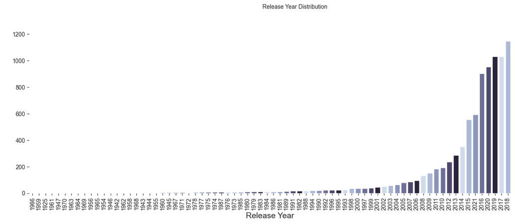

```python
#UNIVARIATE ANALISYS

fig, ax = plt.subplots(1, 1, figsize=(15, 5))
sns.countplot(data = df, x = 'release_year',ax=ax, order = df['release_year'].value_counts(ascending=True).index,palette=palette)
ax.set_xlabel(xlabel='Release Year', size=14)
ax.set_ylabel(ylabel=" ")
sns.despine(bottom=True, left=True)
plt.xticks(rotation=90)
fig.text(0.5, 1,"Release Year Distribution")
plt.show()
```

```python
df_year_added = df[df['date_added'].notna()]
df_year_added['year_added'] = pd.DatetimeIndex(df_year_added['date_added']).year
```

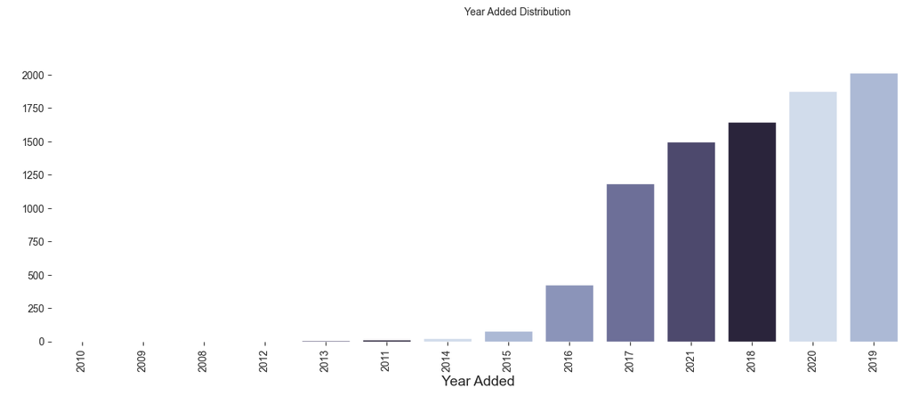

```python
fig, ax = plt.subplots(1, 1, figsize=(15, 5))
sns.countplot(data = df_year_added, x = 'year_added',ax=ax, order = df_year_added['year_added'].value_counts(ascending=True).index,palette=palette)
ax.set_xlabel(xlabel='Year Added', size=14)
ax.set_ylabel(ylabel=" ")
sns.despine(bottom=True, left=True)
plt.xticks(rotation=90)
fig.text(0.5, 1,"Year Added Distribution")
plt.show()
```

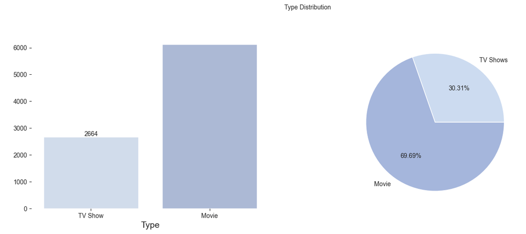

```python
fig, ax = plt.subplots(1, 2, figsize=(15, 5))
sns.countplot(data = df, x = 'type',ax=ax[0], order = df['type'].value_counts(ascending=True).index,palette=palette)
ax[0].set_xlabel(xlabel='Type', size=14)
ax[0].set_ylabel(ylabel=" ")
ax[0].bar_label(ax[0].containers[0])
sns.despine(bottom=True, left=True)
df['type'].value_counts(ascending=True).plot(kind='pie',ax=ax[1],autopct="%.2f%%",colors=palette,labels=['TV Shows','Movie'])
ax[1].set_xlabel(xlabel=" ")
ax[1].set_ylabel(ylabel=" ")
fig.text(0.5, 1,"Type Distribution")
plt.show()
```

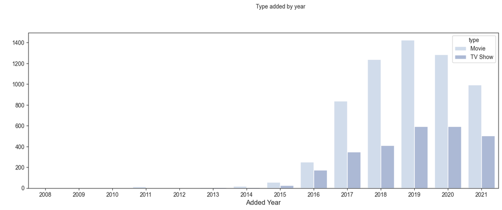

```python
#MULTIVARIATE ANALISYS: Type by added year

fig, ax = plt.subplots(1, 1, figsize=(15, 5))
sns.countplot(data=df_year_added,x='year_added',hue='type',palette=palette)
ax.set_xlabel(xlabel='Added Year', size=12)
ax.set_ylabel(ylabel=' ')
fig.text(0.5, 1,"Type added by year")
plt.show()
```

```python
#GENRES ANALISYS
#Get Main Genres from all set of data. Listed_in column consist of multiple genres. For Wordclouds visualization, I am going to extract a main genre***

def get_secondary_genre(text):
    if len(text.split(","))>1:
        secondary= text.split(",")[1].strip()
    else:
        secondary = text.split(",")[0].strip()
    return secondary


df['main_genre']= df['listed_in'].apply(lambda x: x.split(",")[0])
df['secondary_genre']= df['listed_in'].apply(lambda x: get_secondary_genre(x))
```

```python
df.head()
```

|  | show_id | type | title | director | country | date_added | release_year | rating | duration | listed_in | month | main_genre | secondary_genre |
| --- | --- | --- | --- | --- | --- | --- | --- | --- | --- | --- | --- | --- | --- |
| 0 | s1 | Movie | Dick Johnson Is Dead | Kirsten Johnson | United States | 9/25/2021 | 2020 | Teens - Age above 12 | 90 min | Documentaries | 9 | Documentaries | Documentaries |
| 1 | s3 | TV Show | Ganglands | Julien Leclercq | France | 9/24/2021 | 2021 | Adults | 1 Season | Crime TV Shows, International TV Shows, TV Act... | 9 | Crime TV Shows | International TV Shows |
| 2 | s6 | TV Show | Midnight Mass | Mike Flanagan | United States | 9/24/2021 | 2021 | Adults | 1 Season | TV Dramas, TV Horror, TV Mysteries | 9 | TV Dramas | TV Horror |
| 3 | s14 | Movie | Confessions of an Invisible Girl | Bruno Garotti | Brazil | 9/22/2021 | 2021 | Kids - with parental guidence | 91 min | Children & Family Movies, Comedies | 9 | Children & Family Movies | Comedies |
| 4 | s8 | Movie | Sankofa | Haile Gerima | United States | 9/24/2021 | 1993 | Adults | 125 min | Dramas, Independent Movies, International Movies | 9 | Dramas | Independent Movies |

```python
#MAPPING GENRES

mapping_genres_dict ={'Documentaries':'Documentaries',
     'British TV Shows': 'International',
     'International TV Shows':'International',
     'Crime TV Shows':'Crime',
    'Docuseries':'Documentaries',
     'TV Dramas':'Dramas',
     'Children & Family Movies':'Children & Family Movies',
     'Dramas':'Dramas',
     'Comedies':'Comedies',
     'TV Comedies':'Comedies',
     'Thrillers':'Thrillers',
     'TV Thrillers':'Thrillers',
     'Horror Movies':'Horror',
     "Kids' TV":"Kids' TV",
     'Action & Adventure':'Action & Adventure',
     'Reality TV':'Reality TV',
     'Anime Series':'Anime',
     'International Movies':'International',
     'Sci-Fi & Fantasy':'Sci-Fi & Fantasy',
       'Classic Movies':'Classic',
     'TV Shows':'TV Shows',
     'Stand-Up Comedy':'Stand-Up Comedy & Talk Shows',
       'TV Action & Adventure':'Action & Adventure',
     'Movies':'Movies',
     'Korean TV Shows':'International',
     'Stand-Up Comedy & Talk Shows':'Stand-Up Comedy & Talk Shows',
       'Classic & Cult TV':'Classic',
     'Anime Features':'Anime',
       'Cult Movies':'Cult',
     'Classic Movies':'Classic',
     'Independent Movies':'Independent Movies',
     'TV Horror':'Horror',
        'Music & Musicals':'Music & Musicals',
       'LGBTQ Movies':'LGBTQ',
     'Sports Movies':'Sport',
          'Spanish-Language TV Shows':'International',
         'Romantic TV Shows':'Romantic',
         'Romantic Movies':'Romantic',
         'TV Action & Adventure':'Action & Adventure',
         'TV Sci-Fi & Fantasy': 'Sci-Fi & Fantasy',
      'International TV Shows':'International',
     'Faith & Spirituality':'Faith & Spirituality',
      'Science & Nature TV':'Science & Nature'
                     }

df['main_genre']=df['main_genre'].map(mapping_genres_dict)
df['secondary_genre']=df['secondary_genre'].map(mapping_genres_dict)
```

```python
df['main_genre'].value_counts()
```

```
main_genre
Dramas                          1666
Comedies                        1329
International                   1155
Documentaries                   1049
Action & Adventure               898
Children & Family Movies         605
Crime                            399
Kids' TV                         385
Stand-Up Comedy & Talk Shows     368
Horror                           286
Anime                            195
Reality TV                       120
Classic                          100
Thrillers                         65
Movies                            53
Romantic                          35
Independent Movies                20
Music & Musicals                  18
TV Shows                          16
Sci-Fi & Fantasy                  14
Cult                              12
LGBTQ                              1
Sport                              1
Name: count, dtype: int64
```

```python
##For all rare genres (LGBTQ, Cult, Sport,Independent Movies),if exists, I'm going to choose secondary genre

df.loc[df['main_genre']=='LGBTQ']
df.loc[df['main_genre'] == 'LGBTQ', ['main_genre']] = df[df['main_genre'] == 'LGBTQ']['secondary_genre']
df.loc[df['main_genre'] == 'Cult', ['main_genre']] = df[df['main_genre'] == 'Cult']['secondary_genre']
df.loc[df['main_genre'] == 'Sport', ['main_genre']] = df[df['main_genre'] == 'Sport']['secondary_genre']
df.loc[df['main_genre'] == 'Independent Movies', ['main_genre']] = df[df['main_genre'] == 'Independent Movies']['secondary_genre']
```

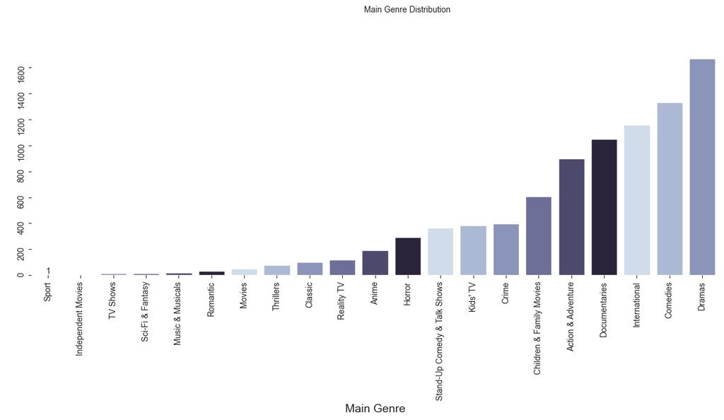

```python
fig, ax = plt.subplots(1, 1, figsize=(15, 5))
sns.countplot(data = df, x = 'main_genre',ax=ax, order = df['main_genre'].value_counts(ascending=True).index,palette=palette)
ax.set_xlabel(xlabel='Main Genre', size=14)
ax.set_ylabel(ylabel=" ")
ax.bar_label(ax.containers[0])
sns.despine(bottom=True, left=True)
ax.tick_params(labelrotation=90)
fig.text(0.5, 1,"Main Genre Distribution")
plt.show()
```

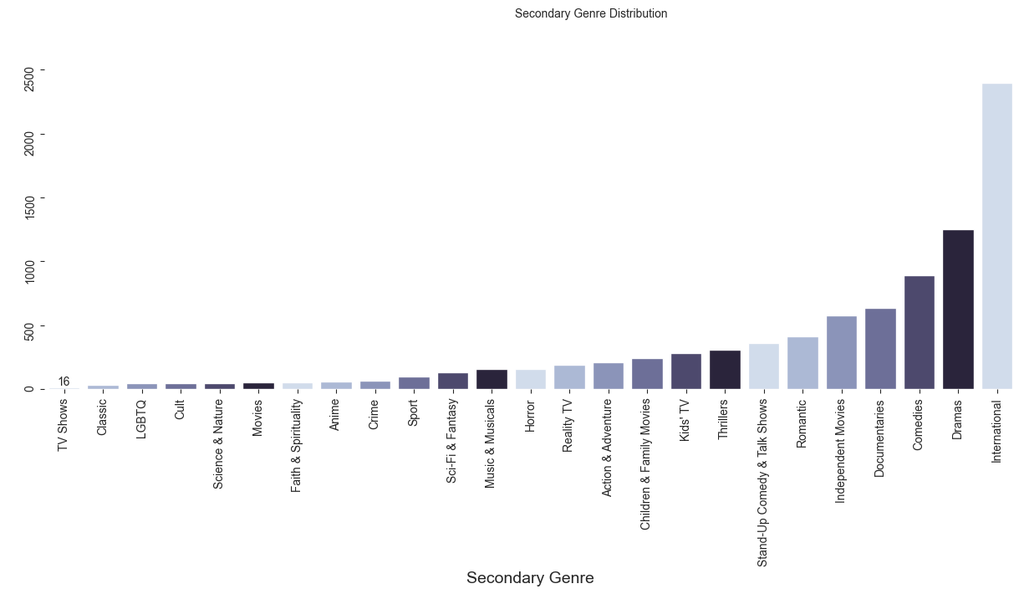

```python
fig, ax = plt.subplots(1, 1, figsize=(15, 5))
sns.countplot(data = df, x = 'secondary_genre',ax=ax, order = df['secondary_genre'].value_counts(ascending=True).index,palette=palette)
ax.set_xlabel(xlabel='Secondary Genre', size=14)
ax.set_ylabel(ylabel=" ")
ax.bar_label(ax.containers[0])
sns.despine(bottom=True, left=True)
ax.tick_params(labelrotation=90)
fig.text(0.5, 1,"Secondary Genre Distribution")
plt.show()
```

```python
print(df.columns)
```

```
Index(['show_id', 'type', 'title', 'director', 'country', 'date_added',
       'release_year', 'rating', 'duration', 'listed_in', 'month',
       'main_genre', 'secondary_genre'],
      dtype='object')
```

```python
import plotly.express as px

# Step 1: Get total content count per country (Top 10)
df_country_viz_total = (
    df_country[["show_id", "country"]]
    .groupby("country")["show_id"]
    .count()
    .reset_index()
    .rename(columns={"show_id": "total_content_count"})
    .sort_values("total_content_count", ascending=False)
    .head(10)
)

# Step 2: Get type-wise count (Movie/TV Show) for these countries
df_country_viz1 = (
    df_country[df_country["country"].isin(df_country_viz_total["country"])]
    .groupby(["country", "type"])["show_id"]
    .count()
    .reset_index()
    .rename(columns={"show_id": "type_count"})
)

# Step 3: Merge and calculate percentage
final1 = df_country_viz_total.merge(df_country_viz1, on="country", how="left")
final1["percentage"] = (final1["type_count"] / final1["total_content_count"]) * 100
final1["percentage"] = final1["percentage"].round(1)
final1["percent_string"] = final1["percentage"].astype(str) + "%"

# Step 4: Visualize
fig2 = px.bar(
    final1,
    x="country",
    y="percentage",
    color="type",
    text="percent_string",
    title="Top 10 Countries: Movie/TV Show Content Split (%)",
    labels={"percentage": "Content Share (%)"}
)
fig2.update_traces(textposition="outside")
fig2.update_layout(barmode="stack", uniformtext_minsize=8, uniformtext_mode='hide')
fig2.show()
```

[interactive chart not shown]

```python
df['pseudo_description'] = df['title'] + ' is a ' + df['main_genre'] + ' show listed under ' + df['listed_in']
```

```python
import nltk
nltk.download('punkt')
nltk.download('stopwords')
```

```
True
```

```python
def text_preprocessing(columns_pandas, stop_words):
    if pd.isnull(columns_pandas):
        return ""
    tokens = nltk.word_tokenize(columns_pandas)
    tokens = [w for w in tokens if w.isalpha()]
    tokens = [word for word in tokens if word.lower() not in stop_words]
    return " ".join(tokens)
```

```python
df['listed_in']  # This is a valid column
```

```
0                                           Documentaries
1       Crime TV Shows, International TV Shows, TV Act...
2                      TV Dramas, TV Horror, TV Mysteries
3                      Children & Family Movies, Comedies
4        Dramas, Independent Movies, International Movies
                              ...
8785                    International TV Shows, TV Dramas
8786                                             Kids' TV
8787    International TV Shows, Romantic TV Shows, TV ...
8788                                             Kids' TV
8789                                             Kids' TV
Name: listed_in, Length: 8790, dtype: object
```

```python
!pip install nltk
```

```python
import nltk
nltk.download('punkt')
```

```
True
```